# Health Insurance Workshop

Yesid Leonardo López Sierra

3/1/2020

### Introducción

Una empresa de seguros tiene como objetivo encontrar las variables que influyen a la hora de tener un seguro médico. Para esto, una firma de investigación de mercados ha suministrado datos, los cuales pertenecen a una muestra representativa de la población. Cada uno de estos registros tiene: Fecha de recolección, identificador del individuo, sexo, si es o no empleado, ingreso anual, estado civil, tipo de vivienda, número de vehículos, edad, estado de residencia y si tiene o no seguro.  
Este informe tiene como **objetivo** plasmar los hallazgos más importantes del proceso de limpieza y preparación de los datos para identificar la calidad de los datos recolectados y, posteriormente, construir el modelo de analítica. Es por esto que el informe se divide en las siguientes secciones: **Entendimiento del negocio y origen de los datos** donde se identifica el contexto del proyecto de analítica e identifica el origen de los datos. **Detección de anomalías** donde se descubre, corrige y eliminan registros de datos erróneos de la fuente de datos. **Preparación de los datos** donde se seleccionan las características más importantes para, finalmente, analizar los datos. Por último, se presentan las **Conclusiones** de la limpieza y la preparación.

### Entendimiento del negocio y origen de los datos

Una empresa de seguros quiere identificar las variables que influyen para que una persona tenga o no un seguro médico, es por esto que el objetivo del proyecto de analítica es identificarlos, para que así la empresa centre sus esfuerzos en esas variables y aumente la venta de seguros.

A continuación se presentan algunos de los registros del dataset:

```r
# Load Dataset splitted by (;) and map the empty values ("") to NA
insurance_dataset <-
  read.csv2("./base_clientes.csv", na.strings = c("", "NA"))
# Print the first 6 elements
kable(head(insurance_dataset, 6))
```

| date | custid | sex | is.employed | annual_incomeUSD | marital.stat | health.ins | housing.type | vehicle | num.vehicles | age | state.of.res |
| --- | --- | --- | --- | --- | --- | --- | --- | --- | --- | --- | --- |
| 10/24/2016 5:09:23 | 2068 | 1 | NA | 11300 | Married | TRUE | Homeowner free and clear | YES | 2 | 49 | Michigan |
| 10/24/2016 5:09:55 | 2073 | 1 | NA | 0 | Married | TRUE | Rented | YES | 3 | 40 | Florida |
| 10/24/2016 5:13:07 | 2848 | 2 | TRUE | 4500 | Never Married | FALSE | Rented | YES | 3 | 22 | Georgia |
| 10/24/2016 5:14:17 | 5641 | 2 | TRUE | 20000 | Never Married | FALSE | Occupied with no rent | NO | 4 | 22 | New Mexico |
| 10/24/2016 5:14:25 | 6369 | 1 | TRUE | 12000 | Never Married | TRUE | Rented | YES | 1 | 31 | Florida |
| 10/24/2016 5:16:43 | 8322 | 1 | TRUE | 180000 | Never Married | TRUE | Homeowner with mortgage/loan | YES | 1 | 40 | NewYork |

#### Identificación de la estructura de datos

```r
# Print the data structure
str(insurance_dataset)
```

```
## 'data.frame':    1002 obs. of  12 variables:
##  $ date            : Factor w/ 996 levels "10/24/2016 10:02:16",..: 386 387 388 389 390 391 392 393 394 395 ...
##  $ custid          : int  2068 2073 2848 5641 6369 8322 8521 12195 14989 15917 ...
##  $ sex             : int  1 1 2 2 1 1 2 2 2 1 ...
##  $ is.employed     : logi  NA NA TRUE TRUE TRUE TRUE ...
##  $ annual_incomeUSD: int  11300 0 4500 20000 12000 180000 120000 40000 9400 24000 ...
##  $ marital.stat    : Factor w/ 4 levels "Divorced/Separated",..: 2 2 3 3 3 3 3 2 2 1 ...
##  $ health.ins      : logi  TRUE TRUE FALSE FALSE TRUE TRUE ...
##  $ housing.type    : Factor w/ 4 levels "Homeowner free and clear",..: 1 4 4 3 4 2 1 4 4 1 ...
##  $ vehicle         : Factor w/ 2 levels "NO","YES": 2 2 2 1 2 2 2 2 2 2 ...
##  $ num.vehicles    : int  2 3 3 4 1 1 1 3 2 1 ...
##  $ age             : Factor w/ 78 levels "0","18","19",..: 34 25 6 6 16 25 24 33 29 56 ...
##  $ state.of.res    : Factor w/ 54 levels " New York","Alabama",..: 24 11 12 33 11 36 14 24 15 37 ...
```

Se puede observar que el tipo de estructura de estos datos corresponde a *datos de corte transversal*, ya que, como se identificará posteriormente, la fecha de recolección corresponde a un mismo periodo.

### Detección de anomalías

La estructura de datos de la sección muestra varias anomalías, a continuación se explicará cada una:

#### Formato de variables incorrecto

Los formatos de fecha, sexo y edad no corresponden al tipo de variable:

```r
# Print the variable type for each feature
cat("The variable type for date is:", class(insurance_dataset$date), "\n")
```

```
## The variable type for date is: factor
```

```r
cat("The variable type for sex is:", class(insurance_dataset$sex), "\n")
```

```
## The variable type for sex is: integer
```

```r
cat("The variable type for age is:", class(insurance_dataset$age), "\n")
```

```
## The variable type for age is: factor
```

```r
cat("The variable type for vehicle is:", class(insurance_dataset$vehicle), "\n")
```

```
## The variable type for vehicle is: factor
```

Por lo tanto, se cambia al formato correcto:

```r
# First, convert the date as a Date format instead of a factor
insurance_dataset$date <-
  as.Date(insurance_dataset$date, format = "%m/%d/%Y")
# Second, convert the sex to a factor instead of a integer because it is a qualitative value
insurance_dataset$sex <-
  factor(
    insurance_dataset$sex,
    levels = c("1", "2"),
    labels = c("Female", "Male")
  )
# Third, convert vehicle to boolean because it is a yes or not value
insurance_dataset$vehicle <- as.logical(factor(
  insurance_dataset$vehicle,
  levels = c("YES", "NO"),
  labels = c("True", "False")
))
# Finally, convert the age as a cuantitative value instead of a qualitative. For that, cast to an integer value
# Supressing warnings because it will cast string values to NA
suppressWarnings(insurance_dataset$age <-
  as.integer(as.character(insurance_dataset$age)))
```

Ahora, la estructura del dataset queda de la siguiente forma:

```
## 'data.frame':    1002 obs. of  12 variables:
##  $ date            : Date, format: "2016-10-24" "2016-10-24" ...
##  $ custid          : int  2068 2073 2848 5641 6369 8322 8521 12195 14989 15917 ...
##  $ sex             : Factor w/ 2 levels "Female","Male": 1 1 2 2 1 1 2 2 2 1 ...
##  $ is.employed     : logi  NA NA TRUE TRUE TRUE TRUE ...
##  $ annual_incomeUSD: int  11300 0 4500 20000 12000 180000 120000 40000 9400 24000 ...
##  $ marital.stat    : Factor w/ 4 levels "Divorced/Separated",..: 2 2 3 3 3 3 3 2 2 1 ...
##  $ health.ins      : logi  TRUE TRUE FALSE FALSE TRUE TRUE ...
##  $ housing.type    : Factor w/ 4 levels "Homeowner free and clear",..: 1 4 4 3 4 2 1 4 4 1 ...
##  $ vehicle         : logi  TRUE TRUE TRUE FALSE TRUE TRUE ...
##  $ num.vehicles    : int  2 3 3 4 1 1 1 3 2 1 ...
##  $ age             : int  49 40 22 22 31 40 39 48 44 70 ...
##  $ state.of.res    : Factor w/ 54 levels " New York","Alabama",..: 24 11 12 33 11 36 14 24 15 37 ...
```

#### Duplicados

Se busca si existen datos duplicados por id, pues este valor es un identificador único:

| ¿is duplicated? | Frecuency |
| --- | --- |
| FALSE | 1000 |
| TRUE | 2 |

Debido a que hay datos duplicados, se procede a validar que todos sus valores estén repetidos para eliminarlos.

```r
# Find duplicated values
duplicatedIds <- insurance_dataset$custid[duplicated(insurance_dataset$custid)]
duplicatedDF <- subset(insurance_dataset, custid %in% duplicatedIds)
kable(duplicatedDF)
```

|  | date | custid | sex | is.employed | annual_incomeUSD | marital.stat | health.ins | housing.type | vehicle | num.vehicles | age | state.of.res |
| --- | --- | --- | --- | --- | --- | --- | --- | --- | --- | --- | --- | --- |
| 876 | 2016-10-25 | 1238436 | Female | NA | 0 | Married | FALSE | Rented | TRUE | 2 | 25 | Tennessee |
| 877 | 2016-10-25 | 1238436 | Female | NA | 0 | Married | FALSE | Rented | TRUE | 2 | 25 | Tennessee |
| 1001 | 2016-10-27 | 1414286 | Female | FALSE | 20900 | Married | FALSE | Rented | TRUE | 2 | 36 | New York |
| 1002 | 2016-10-27 | 1414286 | Female | FALSE | 20900 | Married | FALSE | Rented | TRUE | 2 | 36 | New York |

Finalmente, se eliminan teniendo como resultado lo siguiente:

```r
# Due to the id should not be duplicated we delete the copies
insurance_dataset <- unique(insurance_dataset)
# There should not be duplicated data
kable(table(duplicated(insurance_dataset$custid)), col.names= c("¿Duplicates?", "Frecuency"))
```

| ¿Duplicates? | Frecuency |
| --- | --- |
| FALSE | 1000 |

#### Campos Vacíos

Al hacer la carga de datos, se reemplazaron los valores vacíos ("") po NAs. A continuación se imprime un resume de cada característica:

```r
# MISSING VALUES
summary(insurance_dataset)
```

```
##       date                custid            sex      is.employed
##  Min.   :2016-10-24   Min.   :   2068   Female:439   Mode :logical
##  1st Qu.:2016-10-24   1st Qu.: 345667   Male  :560   FALSE:73
##  Median :2016-10-24   Median : 693403   NA's  :  1   TRUE :598
##  Mean   :2016-10-24   Mean   : 698500                NA's :329
##  3rd Qu.:2016-10-24   3rd Qu.:1044606
##  Max.   :2016-10-27   Max.   :1414286
##
##  annual_incomeUSD             marital.stat health.ins
##  Min.   : -8700   Divorced/Separated:155   Mode :logical
##  1st Qu.: 14600   Married           :515   FALSE:159
##  Median : 35000   Never Married     :233   TRUE :840
##  Mean   : 53528   Widowed           : 96   NA's :1
##  3rd Qu.: 67000   NA's              :  1
##  Max.   :615000
##  NA's   :1
##                        housing.type  vehicle         num.vehicles
##  Homeowner free and clear    :156   Mode :logical   Min.   :1.000
##  Homeowner with mortgage/loan:412   FALSE:113       1st Qu.:1.000
##  Occupied with no rent       : 11   TRUE :886       Median :2.000
##  Rented                      :364   NA's :1         Mean   :2.042
##  NA's                        : 57                   3rd Qu.:3.000
##                                                     Max.   :6.000
##                                                     NA's   :112
##       age               state.of.res
##  Min.   :  0.00   California  :100
##  1st Qu.: 38.00   Pennsylvania: 70
##  Median : 50.00   New York    : 67
##  Mean   : 51.29   Texas       : 56
##  3rd Qu.: 63.00   Michigan    : 52
##  Max.   :225.00   (Other)     :654
##  NA's   :4        NA's        :  1
```

Se puede observar que hay campos vacíos para sex, is.employed, annual_incomeUSD, marital.stat, health.ins, housing.type, vehicle, num.vehicles, age y state.of.res.

Primero se revisa el registro vacío para sexo:

```r
# First, let's search the only one value for sex
missing <- insurance_dataset[which(is.na(insurance_dataset$sex)), ]
kable(missing)
```

|  | date | custid | sex | is.employed | annual_incomeUSD | marital.stat | health.ins | housing.type | vehicle | num.vehicles | age | state.of.res |
| --- | --- | --- | --- | --- | --- | --- | --- | --- | --- | --- | --- | --- |
| 69 | 2016-10-24 | 84879 | NA | NA | NA | NA | NA | NA | NA | NA | NA | NA |

Debido a que es un registro que tiene muchos valores nulos, se procede a borrarlo.

```r
# Looks like that row has a lot of missing values for the cols, thats why that row is deleted
library(tidyr)
insurance_dataset <- insurance_dataset %>% drop_na(sex)
summary(insurance_dataset)
```

```
##       date                custid            sex      is.employed
##  Min.   :2016-10-24   Min.   :   2068   Female:439   Mode :logical
##  1st Qu.:2016-10-24   1st Qu.: 347156   Male  :560   FALSE:73
##  Median :2016-10-24   Median : 693571                TRUE :598
##  Mean   :2016-10-24   Mean   : 699114                NA's :328
##  3rd Qu.:2016-10-24   3rd Qu.:1045176
##  Max.   :2016-10-27   Max.   :1414286
##
##  annual_incomeUSD             marital.stat health.ins
##  Min.   : -8700   Divorced/Separated:155   Mode :logical
##  1st Qu.: 14600   Married           :515   FALSE:159
##  Median : 35000   Never Married     :233   TRUE :840
##  Mean   : 53528   Widowed           : 96
##  3rd Qu.: 67000
##  Max.   :615000
##
##                        housing.type  vehicle         num.vehicles
##  Homeowner free and clear    :156   Mode :logical   Min.   :1.000
##  Homeowner with mortgage/loan:412   FALSE:113       1st Qu.:1.000
##  Occupied with no rent       : 11   TRUE :886       Median :2.000
##  Rented                      :364                   Mean   :2.042
##  NA's                        : 56                   3rd Qu.:3.000
##                                                     Max.   :6.000
##                                                     NA's   :111
##       age               state.of.res
##  Min.   :  0.00   California  :100
##  1st Qu.: 38.00   Pennsylvania: 70
##  Median : 50.00   New York    : 67
##  Mean   : 51.29   Texas       : 56
##  3rd Qu.: 63.00   Michigan    : 52
##  Max.   :225.00   Ohio        : 51
##  NA's   :3        (Other)     :603
```

La información anterior muestra que hay 4 variables con NA: is.employed, housing.type, age and num.vehicles.

Para solventar los campos vacíos de la cantidad de vehículos, se analiza si hay relación entre esta variable y tener o no vehículo:

```r
# Let's try to find any relationship between NA num vehicles and vehicles:
summary(insurance_dataset[(insurance_dataset$vehicle == FALSE & insurance_dataset$num.vehicles == 0), c("vehicle", "num.vehicles")])
```

```
##  vehicle         num.vehicles
##  Mode:logical   Min.   : NA
##  NA's:111       1st Qu.: NA
##                 Median : NA
##                 Mean   :NaN
##                 3rd Qu.: NA
##                 Max.   : NA
##                 NA's   :111
```

```r
# Override the NA to cero because if there is a NA value, then there is a False for Vehicle
# value for the vehicle feature
insurance_dataset$num.vehicles <-
  ifelse(is.na(insurance_dataset$num.vehicles),
         0,
         insurance_dataset$num.vehicles)
```

Por otro lado, se reemplazaran las edades con NA por cero:

```r
# For NAs for age, let's save these values as 0.
insurance_dataset$age <-
  ifelse(is.na(insurance_dataset$age), 0, insurance_dataset$age)
summary(insurance_dataset)
```

```
##       date                custid            sex      is.employed
##  Min.   :2016-10-24   Min.   :   2068   Female:439   Mode :logical
##  1st Qu.:2016-10-24   1st Qu.: 347156   Male  :560   FALSE:73
##  Median :2016-10-24   Median : 693571                TRUE :598
##  Mean   :2016-10-24   Mean   : 699114                NA's :328
##  3rd Qu.:2016-10-24   3rd Qu.:1045176
##  Max.   :2016-10-27   Max.   :1414286
##
##  annual_incomeUSD             marital.stat health.ins
##  Min.   : -8700   Divorced/Separated:155   Mode :logical
##  1st Qu.: 14600   Married           :515   FALSE:159
##  Median : 35000   Never Married     :233   TRUE :840
##  Mean   : 53528   Widowed           : 96
##  3rd Qu.: 67000
##  Max.   :615000
##
##                        housing.type  vehicle         num.vehicles
##  Homeowner free and clear    :156   Mode :logical   Min.   :0.000
##  Homeowner with mortgage/loan:412   FALSE:113       1st Qu.:1.000
##  Occupied with no rent       : 11   TRUE :886       Median :2.000
##  Rented                      :364                   Mean   :1.815
##  NA's                        : 56                   3rd Qu.:2.000
##                                                     Max.   :6.000
##
##       age               state.of.res
##  Min.   :  0.00   California  :100
##  1st Qu.: 38.00   Pennsylvania: 70
##  Median : 50.00   New York    : 67
##  Mean   : 51.14   Texas       : 56
##  3rd Qu.: 63.00   Michigan    : 52
##  Max.   :225.00   Ohio        : 51
##                   (Other)     :603
```

Finalmente, se puede observar que hay solo dos variables con NAs: is.employed con 328 registros (33% de los datos) y housing.type con 56 (6% de los datos). Debido a que housing.type tiene un porcentaje pequeño de datos, es seguro eliminarlo. Sin embargo, no se puede hacer lo mismo con la otra variable ya que representa la tercera parte de los datos.

```r
# There are just two variables with NA's: is.employed with 328 (33% of the data) and
# housing.type with 56 (6% of the data). Due to housing.type has a narrow percent of
# the data it is safe to drop these customers, but not for is.employed because
# it is the third part of the data.
insurance_dataset <- insurance_dataset %>% drop_na(housing.type)
```

Para la variable is.employed se llena con un nuevo valor que se llama otro. Este nuevo valor representa a aquellas personas que no pertenecen al mundo laboral, aquí se agrupan los estudiantes, retirados, los que no reciben dinero, etc.

```r
# For is.employed let's replace the NA's for a new value that encodes for someone who is
# not in active in the actual workforce
insurance_dataset$is.employed <-
  ifelse(
    is.na(insurance_dataset$is.employed),
    "Other",
    ifelse(
      insurance_dataset$is.employed == TRUE,
      "Employee",
      "Not Employee"
    )
  )
insurance_dataset$is.employed <-
  factor(insurance_dataset$is.employed)
```

Finalmente, se tiene como resultado de esta sección lo siguiente un conjunto de datos sin valores vacíos. Sin embargo, como se observará posteriormente, hay ciertos datos que no tienen mucho sentido. En la siguiente sección se descubrirán y se trataran a este tipo de datos.

#### Outliers

```
##       date                custid            sex            is.employed
##  Min.   :2016-10-24   Min.   :   2068   Female:424   Employee    :590
##  1st Qu.:2016-10-24   1st Qu.: 344614   Male  :519   Not Employee: 73
##  Median :2016-10-24   Median : 706135                Other       :280
##  Mean   :2016-10-24   Mean   : 699426
##  3rd Qu.:2016-10-24   3rd Qu.:1045176
##  Max.   :2016-10-27   Max.   :1414286
##
##  annual_incomeUSD             marital.stat health.ins
##  Min.   : -8700   Divorced/Separated:149   Mode :logical
##  1st Qu.: 17000   Married           :506   FALSE:137
##  Median : 37200   Never Married     :198   TRUE :806
##  Mean   : 56339   Widowed           : 90
##  3rd Qu.: 70000
##  Max.   :615000
##
##                        housing.type  vehicle         num.vehicles
##  Homeowner free and clear    :156   Mode :logical   Min.   :0.00
##  Homeowner with mortgage/loan:412   FALSE:57        1st Qu.:1.00
##  Occupied with no rent       : 11   TRUE :886       Median :2.00
##  Rented                      :364                   Mean   :1.92
##                                                     3rd Qu.:2.00
##                                                     Max.   :6.00
##
##       age               state.of.res
##  Min.   :  0.00   California  : 91
##  1st Qu.: 38.50   New York    : 66
##  Median : 50.00   Pennsylvania: 65
##  Mean   : 51.34   Texas       : 54
##  3rd Qu.: 63.00   Michigan    : 51
##  Max.   :225.00   Illinois    : 49
##                   (Other)     :567
```

Para tener más información de los datos atípicos se usa el diagrama de caja donde se representan mediante círculos.

La primera variable a tratar es el ingreso anual. Primero se cambia la unidad de la variable dividiendo por 1000 y quedando expresados los valores en miles de dólares.

```r
# let's create some box plots to find outliers
# First, change the annal_income unit dividing by 1000
insurance_dataset$annual_incomeUSD <-
  insurance_dataset$annual_incomeUSD / 1000
```

Después, se genera una visualización del ingreso anual expresado en miles de dólares:

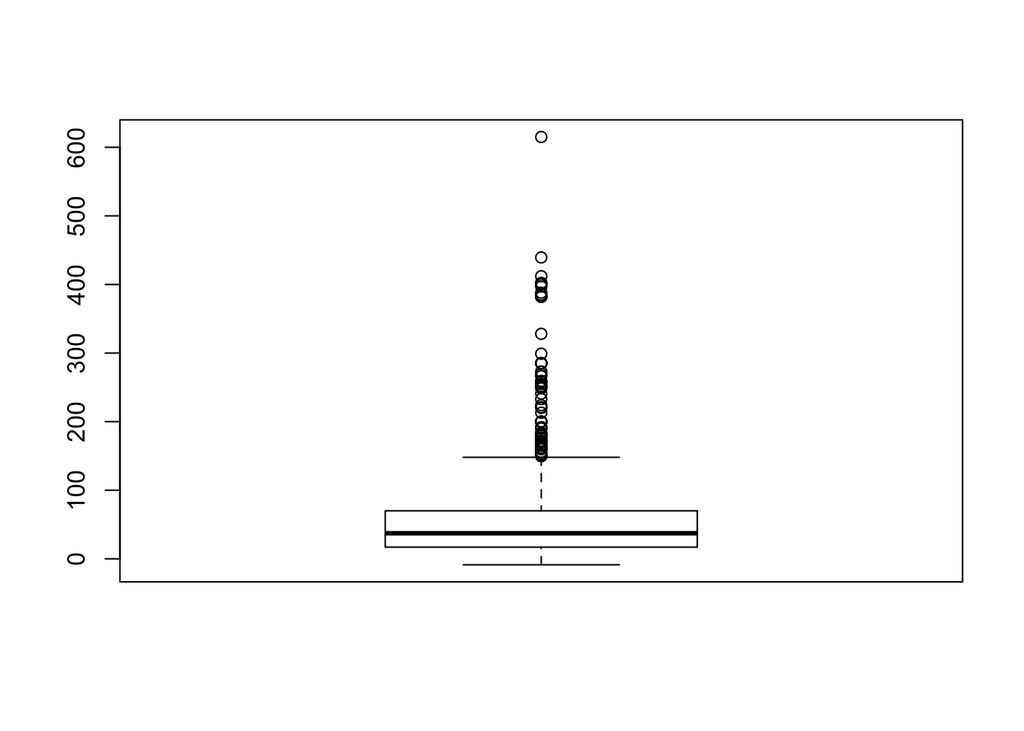

```r
# When the plot is generated, the outliers are more visible
outliers_results <- boxplot(insurance_dataset$annual_incomeUSD)
```

La cantidad de datos atípicos encontrados son:

```r
cat("There are", length(outliers_results$out), "outliers")
```

```
## There are 68 outliers
```

En este caso se imputa con la mediana los outliers:

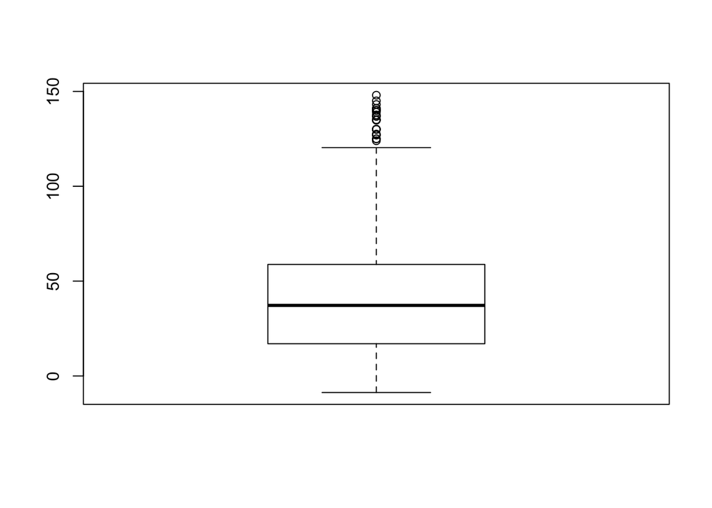

```r
# Then let's use simple imputation to replace the annual income outliers for the annual income median
insurance_dataset$annual_incomeUSD <-
  ifelse(
    insurance_dataset$annual_incomeUSD %in% outliers_results$out,
    median(insurance_dataset$annual_incomeUSD),
    insurance_dataset$annual_incomeUSD
  )
# Then the plot has less outliers now
outliers_results <- boxplot(insurance_dataset$annual_incomeUSD)
```

```r
cat("There are", length(outliers_results$out), "outliers")
```

```
## There are 26 outliers
```

Ahora la cantidad de datos atípicos se redujo a 26 datos. Debido a que corresponde al 2.7600849% de los datos, se deja hasta ese punto.

La segunda variable con datos atípicos es la edad:

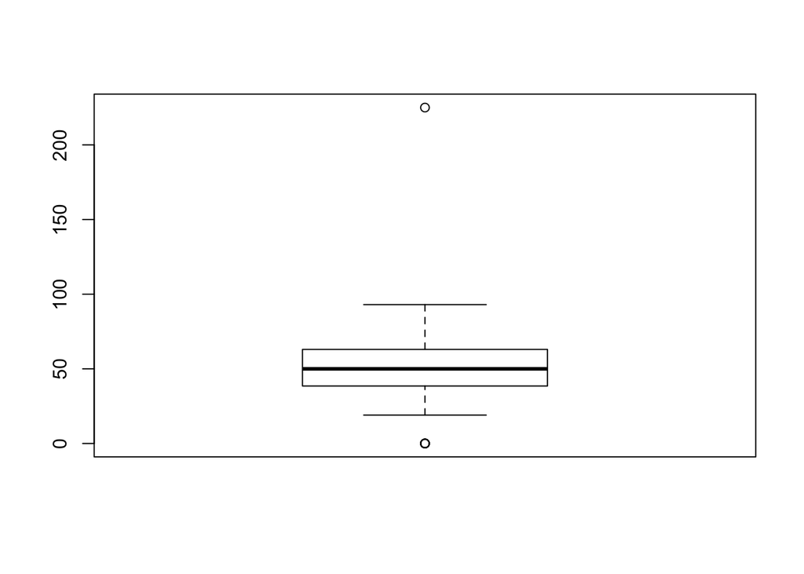

```r
# The second value with outliers is age
outliers_results <- boxplot(insurance_dataset$age)
```

```r
cat("There are", length(outliers_results$out), "outliers")
```

```
## There are 7 outliers
```

Se hace imputación simple con la mediana:

```r
# then impute values using the median too
insurance_dataset$age <-
  ifelse(
    insurance_dataset$age %in% outliers_results$out,
    median(insurance_dataset$age),
    insurance_dataset$age
  )
```

Obteniendo como resultado un diagrama sin outliers:

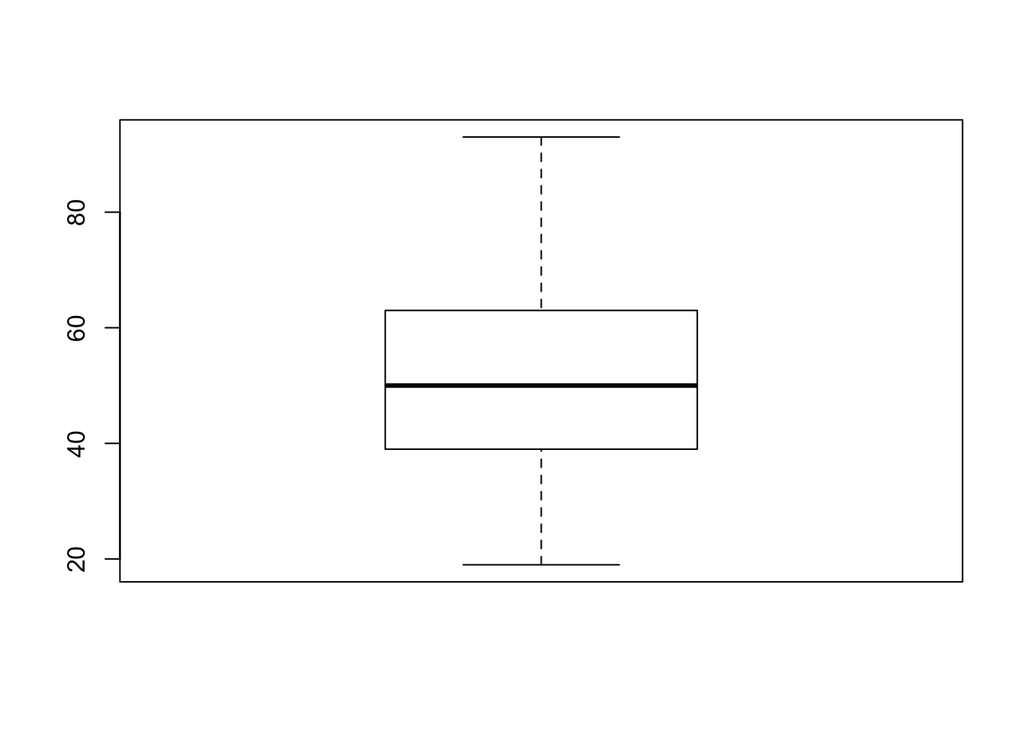

```r
# Then the plot has not outliers now
outliers_results <- boxplot(insurance_dataset$age)
```

#### Valores inválidos

En esta sección se tratan a aquellos valores que no corresponden al rango de los valores de la variable.

```
##       date                custid            sex            is.employed
##  Min.   :2016-10-24   Min.   :   2068   Female:424   Employee    :590
##  1st Qu.:2016-10-24   1st Qu.: 344614   Male  :519   Not Employee: 73
##  Median :2016-10-24   Median : 706135                Other       :280
##  Mean   :2016-10-24   Mean   : 699426
##  3rd Qu.:2016-10-24   3rd Qu.:1045176
##  Max.   :2016-10-27   Max.   :1414286
##
##  annual_incomeUSD             marital.stat health.ins
##  Min.   : -8.70   Divorced/Separated:149   Mode :logical
##  1st Qu.: 17.00   Married           :506   FALSE:137
##  Median : 37.20   Never Married     :198   TRUE :806
##  Mean   : 41.54   Widowed           : 90
##  3rd Qu.: 58.80
##  Max.   :148.00
##
##                        housing.type  vehicle         num.vehicles
##  Homeowner free and clear    :156   Mode :logical   Min.   :0.00
##  Homeowner with mortgage/loan:412   FALSE:57        1st Qu.:1.00
##  Occupied with no rent       : 11   TRUE :886       Median :2.00
##  Rented                      :364                   Mean   :1.92
##                                                     3rd Qu.:2.00
##                                                     Max.   :6.00
##
##       age              state.of.res
##  Min.   :19.00   California  : 91
##  1st Qu.:39.00   New York    : 66
##  Median :50.00   Pennsylvania: 65
##  Mean   :51.47   Texas       : 54
##  3rd Qu.:63.00   Michigan    : 51
##  Max.   :93.00   Illinois    : 49
##                  (Other)     :567
```

En este caso se imputa con la mediana esos valores inválidos:

```r
# INVALID VALUES
# First, let's impute with the median those data with income <= 0
insurance_dataset$annual_incomeUSD <-
  ifelse(
    insurance_dataset$annual_incomeUSD <= 0,
    median(insurance_dataset$annual_incomeUSD),
    insurance_dataset$annual_incomeUSD
  )
```

La siguiente variable a analizar es aquellos registron con una cantidad de vehículos superior a cero pero con FALSE en la columna de Vehículo;

```r
# Second, delete the row with inconsistency because
# it has no vehicule but with 4 num vehicles at the same time
kable(insurance_dataset[insurance_dataset$vehicle == FALSE &
                    insurance_dataset$num.vehicles > 0,])
```

|  | date | custid | sex | is.employed | annual_incomeUSD | marital.stat | health.ins | housing.type | vehicle | num.vehicles | age | state.of.res |
| --- | --- | --- | --- | --- | --- | --- | --- | --- | --- | --- | --- | --- |
| 4 | 2016-10-24 | 5641 | Male | Employee | 20 | Never Married | FALSE | Occupied with no rent | FALSE | 4 | 22 | New Mexico |

En este caso se borra el registro:

```r
insurance_dataset <-
  insurance_dataset[!(insurance_dataset$vehicle == FALSE &
                        insurance_dataset$num.vehicles > 0),]
```

La variable state.of.res tiene valores inconsistentes, estos comprenden espacios de más al inicio o al final, o estados con nombres incompletos como " New York“,”NewYork“,”Suth Caroli", etc:

```r
# Third, trim state.of.res values because there are repited values
# that start or finishwith a whitespace. For example, New york
summary(insurance_dataset$state.of.res)
```

```
##      New York       Alabama        Alaska         Arizo       Arizona
##             1            10             3             6             3
##      Arkansas    California      Colorado   Connecticut      Delaware
##             6            91            11            14             1
##       Florida       Georgia        Hawaii         Idaho      Illinois
##            45            24             4             3            49
##         India          Iowa        Kansas      Kentucky       Louisia
##            28            10             4            15            15
##         Maine      Maryland Massachusetts      Michigan     Minnesota
##             5            16            24            51            20
##   Mississippi      Missouri         Monta      Nebraska        Nevada
##             2            19             2             8             4
## New Hampshire    New Jersey    New Mexico      New York     New York
##             5            36             5            66             2
##       NewYork  North Caroli  North Dakota          Ohio      Oklahoma
##             1            15             1            49            11
##        Oregon  Pennsylvania  Rhode Island  South Caroli  South Dakota
##             7            65             2            14             5
##     Tennessee         Texas          Utah       Vermont      Virginia
##            21            54             4             3            26
##    Washington West Virginia     Wisconsin       Wyoming
##            17            12            26             1
```

Se procede a arreglarlas:

```r
insurance_dataset$state.of.res <-
  factor(trimws(insurance_dataset$state.of.res))
# Finally there are some typo for the states, like this one so let's fix them one by one

# Fixing North Carolina
library(plyr)
insurance_dataset$state.of.res <-
  revalue(insurance_dataset$state.of.res,
          c("North Caroli" = "North Carolina"))

# Fixing South Carolina
insurance_dataset$state.of.res <-
  revalue(insurance_dataset$state.of.res,
          c("South Caroli" = "South Carolina"))

# Fixing Arizona
insurance_dataset$state.of.res <-
  revalue(insurance_dataset$state.of.res, c("Arizo" = "Arizona"))

# Fixing Indiana
insurance_dataset$state.of.res <-
  revalue(insurance_dataset$state.of.res, c("India" = "Indiana"))

# Fixing New York
insurance_dataset$state.of.res <-
  revalue(insurance_dataset$state.of.res, c("NewYork" = "New York"))

# Fixing Louisiana
insurance_dataset$state.of.res <-
  revalue(insurance_dataset$state.of.res, c("Louisia" = "Louisiana"))

# Fixing Montana
insurance_dataset$state.of.res <-
  revalue(insurance_dataset$state.of.res, c("Monta" = "Montana"))
```

Se tiene como resultado lo siguiente:

```r
summary(insurance_dataset$state.of.res)
```

```
##        Alabama         Alaska        Arizona       Arkansas     California
##             10              3              9              6             91
##       Colorado    Connecticut       Delaware        Florida        Georgia
##             11             14              1             45             24
##         Hawaii          Idaho       Illinois        Indiana           Iowa
##              4              3             49             28             10
##         Kansas       Kentucky      Louisiana          Maine       Maryland
##              4             15             15              5             16
##  Massachusetts       Michigan      Minnesota    Mississippi       Missouri
##             24             51             20              2             19
##        Montana       Nebraska         Nevada  New Hampshire     New Jersey
##              2              8              4              5             36
##     New Mexico       New York North Carolina   North Dakota           Ohio
##              5             70             15              1             49
##       Oklahoma         Oregon   Pennsylvania   Rhode Island South Carolina
##             11              7             65              2             14
##   South Dakota      Tennessee          Texas           Utah        Vermont
##              5             21             54              4              3
##       Virginia     Washington  West Virginia      Wisconsin        Wyoming
##             26             17             12             26              1
```

### Preparación de los datos

Primero, se borra la columna de fechas debido que no es una variable que influya en tener un seguro. Además, debido a quelos rangos de las fechas solo difieren en 4 días no se puede inferir que la columna hace referencia a periodos de tiempo.

```r
summary(factor(as.character(insurance_dataset$date)))
```

```
## 2016-10-24 2016-10-25 2016-10-26 2016-10-27
##        736        142         32         32
```

Se borra la columna:

```r
# PREPROCESSING STEP
# Delete date column because it does not have a big range between dates
# also does not provide us enough value
insurance_dataset <-
  insurance_dataset[, names(insurance_dataset) != "date"]
```

Lo mismo pasa con el id del cliente pues debido a que corresponde a valores únicos de cada individuo no influye en la variable objetivo:

```r
# The same for custid because it is unique and for the vehicle col because can be inferred with num.vehicles
insurance_dataset <-
  insurance_dataset[, !names(insurance_dataset) %in% c("custid", "vehicle")]
```

Se procede a crear una nueva columna que dice si una persona es dueña o no de una casa independientemente de que haya o no pagado el crédito:

```r
# Add is.house.owner column if it is Homeowner free and clear or Homeowner with mortgage/loan
insurance_dataset$is.house.owner <-
  ifelse(
    insurance_dataset$housing.type %in% c("Homeowner free and clear", "Homeowner with mortgage/loan"),
    T,
    F
  )
```

Finalmente se añade una nueva columna que agrupa los estados por las 4 regiones que utiliza el Bureau de Estadísticas de EEUU:

```r
# Finally, add bureau.cardinal.point that groups some states
insurance_dataset$bureau.cardinal.point = ifelse(
  insurance_dataset$state.of.res %in% northeast,
  "Northeast",
  ifelse(
    insurance_dataset$state.of.res %in% midwest,
    "Midwest",
    ifelse(
      insurance_dataset$state.of.res %in% south,
      "South",
      ifelse(insurance_dataset$state.of.res %in% west,
             "West",
             "NA")
    )
  )
)
insurance_dataset$bureau.cardinal.point = factor(insurance_dataset$bureau.cardinal.point)
```

Se procede a borrar la columna de state.of.res pues la variable anterior se encarga de agrupar sus valores:

```r
# Delete state.of.res because bureau.cardinal.point creates a set
# for these values
insurance_dataset <-
  insurance_dataset[, names(insurance_dataset) != "state.of.res"]
```

Finalmente, se reordena las columnas por temas y se obtiene lo siguiente:

```r
# Now, the work is done by reordering the column names
insurance_dataset <-
  insurance_dataset[, c(
    "sex",
    "age",
    "marital.stat",
    "housing.type",
    "is.house.owner",
    "bureau.cardinal.point",
    "is.employed",
    "annual_incomeUSD",
    "num.vehicles",
    "health.ins"
  )]

# Thes are the results!
str(insurance_dataset)
```

```
## 'data.frame':    942 obs. of  10 variables:
##  $ sex                  : Factor w/ 2 levels "Female","Male": 1 1 2 1 1 2 2 2 1 1 ...
##  $ age                  : num  49 40 22 31 40 39 48 44 70 46 ...
##  $ marital.stat         : Factor w/ 4 levels "Divorced/Separated",..: 2 2 3 3 3 3 2 2 1 2 ...
##  $ housing.type         : Factor w/ 4 levels "Homeowner free and clear",..: 1 4 4 4 2 1 4 4 1 2 ...
##  $ is.house.owner       : logi  TRUE FALSE FALSE FALSE TRUE TRUE ...
##  $ bureau.cardinal.point: Factor w/ 4 levels "Midwest","Northeast",..: 1 3 3 3 2 4 1 1 3 3 ...
##  $ is.employed          : Factor w/ 3 levels "Employee","Not Employee",..: 3 3 1 1 1 1 1 3 1 3 ...
##  $ annual_incomeUSD     : num  11.3 37.2 4.5 12 37.2 120 40 9.4 24 7 ...
##  $ num.vehicles         : num  2 3 3 1 1 1 3 2 1 2 ...
##  $ health.ins           : logi  TRUE TRUE FALSE TRUE TRUE TRUE ...
```

```r
summary(insurance_dataset)
```

```
##      sex           age                   marital.stat
##  Female:424   Min.   :19.0   Divorced/Separated:149
##  Male  :518   1st Qu.:39.0   Married           :506
##               Median :50.0   Never Married     :197
##               Mean   :51.5   Widowed           : 90
##               3rd Qu.:63.0
##               Max.   :93.0
##                        housing.type is.house.owner  bureau.cardinal.point
##  Homeowner free and clear    :156   Mode :logical   Midwest  :270
##  Homeowner with mortgage/loan:412   FALSE:374       Northeast:224
##  Occupied with no rent       : 10   TRUE :568       South    :287
##  Rented                      :364                   West     :161
##
##
##        is.employed  annual_incomeUSD  num.vehicles   health.ins
##  Employee    :589   Min.   :  0.03   Min.   :0.000   Mode :logical
##  Not Employee: 73   1st Qu.: 21.60   1st Qu.:1.000   FALSE:136
##  Other       :280   Median : 37.20   Median :2.000   TRUE :806
##                     Mean   : 43.71   Mean   :1.918
##                     3rd Qu.: 58.90   3rd Qu.:2.000
##                     Max.   :148.00   Max.   :6.000
```

```r
kable(head(insurance_dataset))
```

|  | sex | age | marital.stat | housing.type | is.house.owner | bureau.cardinal.point | is.employed | annual_incomeUSD | num.vehicles | health.ins |
| --- | --- | --- | --- | --- | --- | --- | --- | --- | --- | --- |
| 1 | Female | 49 | Married | Homeowner free and clear | TRUE | Midwest | Other | 11.3 | 2 | TRUE |
| 2 | Female | 40 | Married | Rented | FALSE | South | Other | 37.2 | 3 | TRUE |
| 3 | Male | 22 | Never Married | Rented | FALSE | South | Employee | 4.5 | 3 | FALSE |
| 5 | Female | 31 | Never Married | Rented | FALSE | South | Employee | 12.0 | 1 | TRUE |
| 6 | Female | 40 | Never Married | Homeowner with mortgage/loan | TRUE | Northeast | Employee | 37.2 | 1 | TRUE |
| 7 | Male | 39 | Never Married | Homeowner free and clear | TRUE | West | Employee | 120.0 | 1 | TRUE |

### Conclusiones

A continuación se presentan los hallazgos encontrados del proceso de limpieza y preparación de los datos. Lo primero que se pudo encontrar era la existencia de dos registros duplicados, se pudo encontrar una gran cantidad de datos vacíos, entre estos, se resaltan principalmente dos variables: si es empleado o no, y el tipo de hogar del individuo. Se pudo encontrar que cerca de la tercera parte de los datos carecía de un valor para saber si era empleado o no, por lo tanto, se creó una nueva variable que tiene como objetivo representar a las personas que no pertenecen este segmento laboral, por ejemplo, estudiantes, retirados, personas que no reciben dinero, etc. Por otro lado, debido a que las personas que no tenían un tipo de hogar registrado se procedió a eliminar los registros pues solo representaban al 6% de los individuos. Al buscar aquellos registros con datos atípicos, resaltaron principalmente dos variables, el ingreso anual y la edad. Estos fueron tratados de la forma correcta al imputar con la mediana, sin embargo, la variabilidad de la variable del ingreso anual hace muy difícil eliminar los outliers por completo. También se pudo encontrar valores inválidos, entre ellos, el ingreso anual presentaba valores demasiado grandoes y otros menores o iguales a cero. Tambíen, la existencia de estados de los individuos con errores de digitación. Posteriormente, en la etapa de procesamiento de los datos se crearon nuevas variables como si es o no dueño de vivienda y otra que agrupa los estados por las 4 regiones que utiliza el Bureau de Estadísticas de EEUU. También se eliminaron variables no influían en la variable objetivo (identificación, fecha) y otras que fueron eliminadas porque habían otras variables eran inferidas de otras variables (si tiene vehículo o no, y los estados de residencia).

Finalmente, como recomendación se pide a la empresa que revise los valores que corresponde a la variable de ingreso anual por lo que se mencionó anteriormente (outliers y valores inconsistentes) y la cantidad de datos faltantes en la variable de is.employed.Además, se le pide tener cuidado a la hora de digitar/pasar la información (debido a lo evidenciado con los estados de residencia). Por último, se pide recolectar más datos para ampliar el dataset y tener un mejor modelo de clasificación. Sin embargo, con el resultado obtenido de la limpieza y preparación es suficiente para construir la primera versión del modelo.